# VISUALISASI ONLINE RETAIL

**Dataset:** https://archive.ics.uci.edu/ml/datasets/online+retail#\

**Link Ipnyb:** https://github.com/Evann888/Evann888.github.io

**Size:** 541910 rows x 8 columns

**Oleh:** Evan (05211640000114)

**Overview:**

Dataset ini berisi mengenai data transaksional yang terjadi antara Desember 2010 hingga Desember 2011 untuk retail online yang berbasis di UK. Perusahaan menjual suvenir hadiah yang unik. Kustomer dari perusahaan banyak yang berupa wholesaler.

```python
import numpy as np
import pandas as pd
import os
import plotly as pyo
import plotly.graph_objects as go
```

```python
df_retail = pd.read_csv("ecommerce.csv", encoding = "ISO-8859-1")
```

```python
df_retail
```

|  | InvoiceNo | StockCode | Description | Quantity | InvoiceDate | UnitPrice | CustomerID | Country |
| --- | --- | --- | --- | --- | --- | --- | --- | --- |
| 0 | 536365 | 85123A | WHITE HANGING HEART T-LIGHT HOLDER | 6 | 12/1/2010 8:26 | 2.55 | 17850.0 | United Kingdom |
| 1 | 536365 | 71053 | WHITE METAL LANTERN | 6 | 12/1/2010 8:26 | 3.39 | 17850.0 | United Kingdom |
| 2 | 536365 | 84406B | CREAM CUPID HEARTS COAT HANGER | 8 | 12/1/2010 8:26 | 2.75 | 17850.0 | United Kingdom |
| 3 | 536365 | 84029G | KNITTED UNION FLAG HOT WATER BOTTLE | 6 | 12/1/2010 8:26 | 3.39 | 17850.0 | United Kingdom |
| 4 | 536365 | 84029E | RED WOOLLY HOTTIE WHITE HEART. | 6 | 12/1/2010 8:26 | 3.39 | 17850.0 | United Kingdom |
| ... | ... | ... | ... | ... | ... | ... | ... | ... |
| 541904 | 581587 | 22613 | PACK OF 20 SPACEBOY NAPKINS | 12 | 12/9/2011 12:50 | 0.85 | 12680.0 | France |
| 541905 | 581587 | 22899 | CHILDREN'S APRON DOLLY GIRL | 6 | 12/9/2011 12:50 | 2.10 | 12680.0 | France |
| 541906 | 581587 | 23254 | CHILDRENS CUTLERY DOLLY GIRL | 4 | 12/9/2011 12:50 | 4.15 | 12680.0 | France |
| 541907 | 581587 | 23255 | CHILDRENS CUTLERY CIRCUS PARADE | 4 | 12/9/2011 12:50 | 4.15 | 12680.0 | France |
| 541908 | 581587 | 22138 | BAKING SET 9 PIECE RETROSPOT | 3 | 12/9/2011 12:50 | 4.95 | 12680.0 | France |

541909 rows × 8 columns

Penjelasan Kolom:

1. InvoiceNo (numeric+text) Menjelaskan nomor invoice
2. StockCode (numeric+text) Menjelaskan kode stok dari produk yang dijual
3. Description (numeric+text) Menjelaskan mengenai produk yang dijual
4. Quantity (numeric) Menjelaskan mengenai kuantitas produk yang dibeli oleh suatu kostumer/transaksi
5. InvoiceDate (datetime) Menjelaskan mengenai kapan terbelinya suatu produk oleh kustomer
6. UnitPrice (numeric) Harga per unit dari produk yang dibeli
7. CustomerID (numeric) 5 digit id kustomer unik yang memesan produk
8. Country (text) Negara dimana tempat kustomer memesan produk

**Setelah Preprocessing**

```python
df_retail_clean = pd.read_excel("ecommerce_clean.xlsx", encoding = "ISO-8859-1")
```

```python
# Menghapus kolom pertama
df_retail_clean.drop(df_retail_clean.columns[[0]], axis=1, inplace=True)
```

```python
df_retail_clean
```

|  | InvoiceNo | InvoiceDate | year_month | year | month | season | day | hour | StockCode | Product | Quantity | UnitPrice | amount_spent | CustomerID | Country | AMPM |
| --- | --- | --- | --- | --- | --- | --- | --- | --- | --- | --- | --- | --- | --- | --- | --- | --- |
| 0 | 536365 | 2010-12-01 08:26:00 | 201012 | 2010 | 12 | Winter | Wednesday | 8 | 71053 | WHITE METAL LANTERN | 6 | 3.39 | 20.34 | 17850 | United Kingdom | AM |
| 1 | 536365 | 2010-12-01 08:26:00 | 201012 | 2010 | 12 | Winter | Wednesday | 8 | 22752 | SET 7 BABUSHKA NESTING BOXES | 2 | 7.65 | 15.30 | 17850 | United Kingdom | AM |
| 2 | 536365 | 2010-12-01 08:26:00 | 201012 | 2010 | 12 | Winter | Wednesday | 8 | 21730 | GLASS STAR FROSTED T-LIGHT HOLDER | 6 | 4.25 | 25.50 | 17850 | United Kingdom | AM |
| 3 | 536366 | 2010-12-01 08:28:00 | 201012 | 2010 | 12 | Winter | Wednesday | 8 | 22633 | HAND WARMER UNION JACK | 6 | 1.85 | 11.10 | 17850 | United Kingdom | AM |
| 4 | 536366 | 2010-12-01 08:28:00 | 201012 | 2010 | 12 | Winter | Wednesday | 8 | 22632 | HAND WARMER RED POLKA DOT | 6 | 1.85 | 11.10 | 17850 | United Kingdom | AM |
| ... | ... | ... | ... | ... | ... | ... | ... | ... | ... | ... | ... | ... | ... | ... | ... | ... |
| 363114 | 581587 | 2011-12-09 12:50:00 | 201112 | 2011 | 12 | Winter | Friday | 12 | 22613 | PACK OF 20 SPACEBOY NAPKINS | 12 | 0.85 | 10.20 | 12680 | France | AM |
| 363115 | 581587 | 2011-12-09 12:50:00 | 201112 | 2011 | 12 | Winter | Friday | 12 | 22899 | CHILDREN'S APRON DOLLY GIRL | 6 | 2.10 | 12.60 | 12680 | France | AM |
| 363116 | 581587 | 2011-12-09 12:50:00 | 201112 | 2011 | 12 | Winter | Friday | 12 | 23254 | CHILDRENS CUTLERY DOLLY GIRL | 4 | 4.15 | 16.60 | 12680 | France | AM |
| 363117 | 581587 | 2011-12-09 12:50:00 | 201112 | 2011 | 12 | Winter | Friday | 12 | 23255 | CHILDRENS CUTLERY CIRCUS PARADE | 4 | 4.15 | 16.60 | 12680 | France | AM |
| 363118 | 581587 | 2011-12-09 12:50:00 | 201112 | 2011 | 12 | Winter | Friday | 12 | 22138 | BAKING SET 9 PIECE RETROSPOT | 3 | 4.95 | 14.85 | 12680 | France | AM |

363119 rows × 16 columns

Preprocessing data:

1. Menghapus missing value
2. Menghapus duplikasi data
3. Menghapus alphabet pada Kolom StockCode dan InvoiceNo
4. Menghapus kuantitas yang bernilai negative
5. Memecah InvoiceDate menjadi year, month, day, dan hour. Setelah itu, mendapatkan yearmonth berdasarkan kolom year dan month, season berdasarkan month pada UK dan AM/PM berdasarkan hour
6. Menambah kolom amount_spent dari hasil perkalian UnitPrice dan Quantity

## 1. Choropleth Map

Kolom: Country (Spasial), Quantity (Quantitative)

Dibuat dengan cara melakukan group by pada country dan melakukan aggregasi penjumlahan pada kuantitas. Setelah itu divisualisasi dengan memilih Country selain United Kingdom

```python
country_quantity= df_retail_clean.groupby('Country', as_index=False).agg({'Quantity': 'sum'})
not_uk =  country_quantity['Country']!="United Kingdom"
country_quantity_except_uk = country_quantity[not_uk]
```

```python
data = [
    dict(
        type='choropleth',
        locations=country_quantity_except_uk['Country'],
        #          autocolorscale=True,
        z=country_quantity_except_uk['Quantity'],
        locationmode='country names',
        marker=dict(line=dict(color='lightskyblue', width=1)),
        colorbar=dict(title='Kuantitas Produk'),
        colorscale='Reds')
]

fig = go.Figure(data=data)

fig.update_layout(
    title_text='Total Kuantitas Pembelian Produk pada Selain Negara UK',
    geo=dict(showframe=False,
             showcoastlines=False,
             projection_type='equirectangular')
)
pyo.offline.iplot(fig)
```

[interactive chart not shown]

Visualisasi menggunakan Choropleth Map diatas akan menggambarkan total kuantitas produk yang dibeli oleh negara selain United Kingdom. Visualisasi ini menggunakan warna sebagai indikator untuk menentukan total kuantitas terendah dan tertinggi. Semakin tinggi intensitas warna merah, maka semakin tinggi kuantitas produk yang dibeli. Visualisasi ini tidak melibatkan Negara UK, karena Negara UK merupakan negara asal perusahaan yang mempunyai total kuantitas sangat banyak dan akan membuat negara lain warnanya menjadi mirip. Hal itu terjadi karena jumlah total kuantitas pada negara lain kecil bila dibandingkan UK. Visualisasi ini bermanfaat bagi divisi pemasaran dan supply perusahaan mampu untuk menentukan strategi pemasaran dan SCM (Supply Chain Management) yang tepat untuk setiap negara berdasarkan total kuantitas produk yang dijual.

Dapat diketahui bahwa semakin tua warna yang terdapat di suatu negara, maka total kuantitas penjualan produknya akan semakin banyak. Dapat diketahui pula bahwa negara Netherlands adalah negara dengan total penjualan terbanyak dari seluruh negara yang menjadi target penjualan perusahaan. Data yang digunakan merupakan data dari Desember 2010 hingga Desember 2011.

```python
# country_quantity_except_uk.sort_values('Quantity',ascending=False)
```

## 2. Bar Chart

Kolom: Country (Categorical), amount_spent (Quantitative)

Dibuat dengan cara melakukan group by pada country dan melakukan aggregasi penjumlahan pada amount_spent

```python
country_spent = df_retail_clean.groupby('Country', as_index=False).agg({'amount_spent': 'sum'})
```

```python
x=country_spent["Country"]
y=country_spent["amount_spent"]
data = [go.Bar(
    x=x,
    y=y,
    marker={
        'color': y,
        'colorscale': 'Viridis'
    }
)]

fig = go.FigureWidget(data=data)
fig.update_layout(
    title_text='Jumlah Uang yang Diperoleh Berdasarkan Negara (US $)', xaxis={'categoryorder':'total descending'}
)

fig.show()
```

[interactive chart not shown]

```python
# country_spent
```

Visualisasi menggunakan Bar Chart diatas akan menggambarkan penghasilan perusahaan yang diperoleh di setiap negara (satuan us $). Visualisasi ini menggunakan warna gold sebagai indikator negara yang menghasilkan uang tertinggi, dan ketinggian bar chart sebagai indikator rendah tingginya pendapatan yang dihasilkan perusahan pada setiap negara. Visualisasi ini bermanfaat bagi eksekutif untuk menglihat penghasilan yang telah diperoleh pada setiap negara yang menjadi target penjualan perusahaan. Melalui grafik ini, eksekutif dapat menentukan strategi untuk meningkatkan pendapatan di negara yang dianggap potensial.

Dapat diketahui bahwa Negara UK menghasilkan pendapatan yang terbanyak bagi perusahaan (> $6.6 M), disusul oleh Netherland, EIRE, Germany, dan France. Data yang digunakan merupakan data dari Desember 2010 hingga Desember 2011.

## 3. Line Chart

Kolom: year_month (Categorical) dan InvoiceNo (Quantitative)

Dibuat Dengan melakukan group by pada year_month dan menghitung jumlah unik pada InvoiceNo

```python
uniques_invoice_yearmonth = df_retail_clean.groupby('year_month', as_index=False).agg({'InvoiceNo': lambda x: x.nunique()}).sort_index(ascending=True)
```

```python
month = ['Desember 2010', 'Januari 2011', 'Februari 2011', 'Maret 2011', 'April 2011', 'Mei 2011', 'Juni 2011',
         'Juli 2011', 'Agustus 2011', 'September 2011', 'Oktober 2011', 'November 2011', 'Desember 2011']
fig = go.Figure(data=go.Scatter(x=month, y=uniques_invoice_yearmonth['InvoiceNo']))
fig.update_layout(title_text = "Jumlah Pesanan Unik Berdasarkan Waktu",
                	xaxis_title='Waktu',
                   yaxis_title='Jumlah Pesanan')
fig.show()
```

[interactive chart not shown]

Visualisasi menggunakan Line Chart diatas akan menggambarkan jumlah pesanan unik yang terjadi pada perusahaan. Visualisasi ini menggunakan tinggi rendahnya line untuk menggambarkan jumlah pesanan berdasarkan waktu. Semakin tinggi line, maka semakin banyak pesanan pada suatu bulan. Visualisasi ini berfmanfaat agar divisi pemasaran dan supply perusahaan mampu untuk menentukan strategi pemasaran dan SCM (Supply Chain Management) yang tepat untuk setiap bulan berdasarkan jumlah pesanan.

Dapat diketahui dari pergerakan line tersebut bahwa Bulan November terdapat kenaikan pesanan unik secara signifikan, sedangkan bulan Desember langsung mengalami penurunan yang tajam. Berdasarkan fakta tersebut, divisi pemasaran dan supply perlu untuk memikirkan strategi untuk memanagemen Demand yang ada agar bisa menghasilkan cost yang optimum dan permintaan kustomer dapat terpenuhi. Data yang digunakan merupakan data dari Desember 2010 hingga Desember 2011.

```python
# uniques_invoice_yearmonth
```

## 4. Stacked Bar Chart

Kolom: year_month (Categorical), quantity (Quantitative)

```python
df_free = df_retail_clean[df_retail_clean.UnitPrice == 0]
df_not_free = df_retail_clean[df_retail_clean.UnitPrice != 0]

df_free_group = df_free.groupby('year_month', as_index=False).agg({'Quantity': lambda x: x.sum()}).sort_index(ascending=True)
df_not_free_group = df_not_free.groupby('year_month', as_index=False).agg({'Quantity': lambda x: x.sum()}).sort_index(ascending=True)
```

```python
month_not_free = ['Desember 2010', 'Januari 2011', 'Februari 2011', 'Maret 2011', 'April 2011', 'Mei 2011', 'Juni 2011',
         'Juli 2011', 'Agustus 2011', 'September 2011', 'Oktober 2011', 'November 2011', 'Desember 2011']

month_free = ['Desember 2010', 'Januari 2011', 'Maret 2011', 'April 2011', 'Mei 2011',
         'Juli 2011', 'Agustus 2011', 'Oktober 2011', 'November 2011']

trace1 = go.Bar(
    x=month_not_free,
    y=df_not_free_group.Quantity,
    name='Not Free Items'
)
trace2 = go.Bar(
    x=month_free,
    y=df_free_group.Quantity,
    name='Free Items'
)

data = [trace1, trace2]
layout = go.Layout(
    barmode='stack'
)

fig = go.Figure(data=data, layout=layout)

fig.update_layout(title_text = "Jumlah Penjualan Produk berdasarkan Waktu Dikelompokkan berdasarkan Produk Promosi",
                    xaxis_title='Waktu',
                   yaxis_title='Jumlah Produk')

pyo.offline.iplot(fig, filename='stacked-bar')
```

[interactive chart not shown]

```python
month = ['Desember 2010', 'Januari 2011', 'Maret 2011', 'April 2011', 'Mei 2011',
         'Juli 2011', 'Agustus 2011', 'Oktober 2011', 'November 2011']

fig = go.Figure(data=go.Bar(x=month, y=df_free_group.Quantity,
                            hovertext=df_free_group.Quantity))
fig.update_layout(title_text = "Jumlah Detail Produk Gratis Berdasarkan Waktu",
                    xaxis_title='Waktu',
                   yaxis_title='Jumlah Produk Gratis')
fig.update_traces(marker_color='rgb(158,202,225)', marker_line_color='rgb(8,48,107)',
                  marker_line_width=1.5, opacity=0.6)
fig.show()
```

[interactive chart not shown]

Visualisasi menggunakan Stacked Bar Chart, visualisasi ini akan menggambarkan jumlah produk berdasarkan kategori produk promosi yang dijual berdasarkan waktu. Terdapat legenda warna biru yang menggambarkan produk tidak gratis, dan merah yang menggambarkan produk gratis (promosi). Selain itu, tinggi bar merepresentasikan jumlah produk gratis, semakin tinggi bar maka semakin banyak produk gratis yang dijual pada suatu bulan. Visualisasi ini bertujuan untuk mengetahui kapan terdapat produk gratis (unit price = 0) pada perusahaan ini. Manfaat dari visualisasi ini adalah untuk mengetahui pengaruh promosi yang dilakukan terhadap jumlah permintaan dan total penjualan produk. Melalui grafik ini, diharapkan divisi pemasaran dapat memberikan promosi pada waktu yang tepat.

Dapat diketahui dari tinggi Bar chart tersebut bahwa Bulan November terdapat kenaikan produk gratis yang signifikan. Selain itu, terdapat pula peningkatan penjualan produk tidak gratis diatas 600K yang tidak pernah didapatkan pada bulan lainnya. Jadi, diadakannya promosi dapat bepengaruh dengan peningkatan demand. Data yang digunakan merupakan data dari Desember 2010 hingga Desember 2011.

## 5. Heat Map

Kolom: InvoiceNo (Quantitative), Day (Categorical), dan Hour (Categorical)

Dibuat dengan melakukan group by berdasarkan kolom Day, dan Hour setelah itu melakukan aggregasi dengan menghitung jumlan InvoiceNo unik

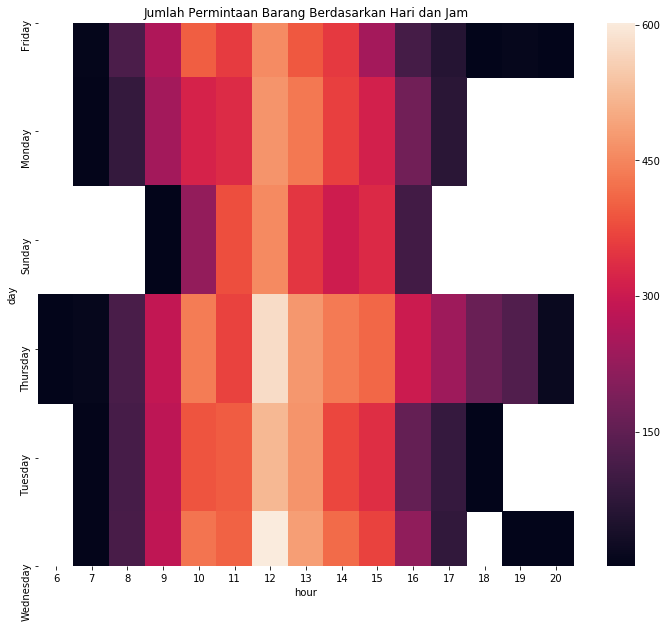

```python
import matplotlib.pyplot as plt
import seaborn as sns

grouped_df  = df_retail_clean.groupby(["day", "hour"])["InvoiceNo"].unique().reset_index()
grouped_df["InvoiceNo"] = grouped_df["InvoiceNo"].apply(len)

grouped_df = grouped_df.pivot('day', 'hour', 'InvoiceNo')

plt.figure(figsize=(12,10))
sns.heatmap(grouped_df)
plt.title("Jumlah Permintaan Barang Berdasarkan Hari dan Jam")
plt.show()
```

Visualisasi menggunakan Heat Map diatas merupakan visualisasi menggunakan 3 kolom yang akan menggambarkan jumlah permintaan barang oleh kustomer berdasarkan waktu (hari dan jam). Terdapat indikator warna hitam yang menggambarkan terjadi sedikit permintaan barang, hingga warna orange muda yang menggambarkan permintaan barang yang tinggi. Visualisasi ini bermanfaat agar pihak eksekutif perusahaan mampu untuk menyiapkan tenaga kerja warehouse yang optimum berdasarkan banyaknya permintaan. Melalui grafik ini diharapkan pihak eksekutif mampu menentukan jumlah pekerja yang optimum berdasarkan permintaan kustomer.

Berdasarkan heat map diatas, dapat diketahui bahwa ternyata permintaan barang sering terjadi pada hari antara pukul 10:00 hingga jam 15:00. Fakta itu dapat dilihat berdarkan warna orange yang tersebar diantara pukul 10:00-15:00. Data yang digunakan merupakan data dari Desember 2010 hingga Desember 2011.